# Tema 08 - Métodos basados en árboles

Árboles de regresión y clasificación, bosques aleatorios y ‘gradient boosting’

Pedro Albarrán

Dpto. de Fundamentos del Análisis Económico. Universidad de Alicante

# Árboles de decisión

## Los datos: los mismos del Tema 07

```r
tienda <- read_csv("data/tienda.csv") |>
  mutate(zona = factor(zona, levels = c("pueblo", "ciudad", "capital")),
         educ = factor(educ))
set.seed(12345678)
part    <- initial_split(tienda, prop = 0.8)
bloques <- vfold_cv(training(part), v = 10)

churn <- read_csv("data/churn_clientes.csv") |>
  select(-id_cliente, -plan_tipo) |>
  mutate(across(where(is.character), factor),
         churn = factor(churn, levels = c("Sí", "No")))
set.seed(12345678)
part_c    <- initial_split(churn, prop = 0.8, strata = churn)
bloques_c <- vfold_cv(training(part_c), v = 10, strata = churn)
```

- Los 404 clientes de la tienda (323 y 81) y los 600 de la empresa de suscripción (479 y 121), con la misma partición y los mismos diez bloques del Tema 07
- El proceso es el del Tema 07, con sus cinco pasos
  - solo cambia el **modelo** del paso 2: en lugar del LASSO, los métodos basados en árboles que se ven en este tema

## De tramos a mano a cortes elegidos por los datos

- En el Tema 05 aproximamos la relación no lineal entre ventas y edad con **tramos** de edad elegidos a mano: cada tramo predice su media
- Cuantos más tramos, mejor ajuste
- Con una **interacción** entre el tramo y la edad, cada tramo tiene además su propia pendiente
- Pero ¿dónde cortamos? ¿Cuántos tramos? ¿Qué interacciones?
- Los métodos de este tema eligen los cortes con los datos, en lugar de a mano

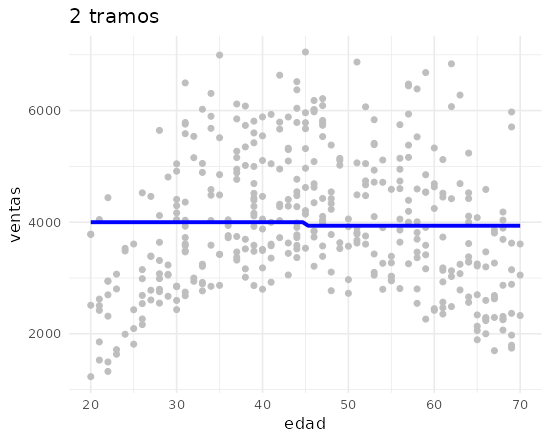

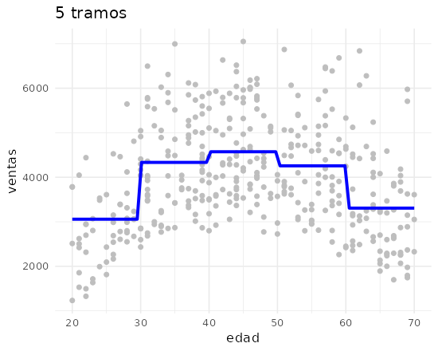

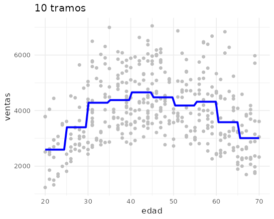

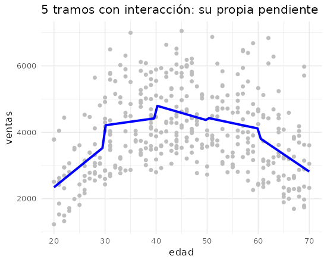

## Árboles de decisión

- Un **árbol de decisión** es un diagrama de flujo con reglas para segmentar el espacio de los regresores en regiones más simples (más detalles)
  - cada división deja grupos más homogéneos o «puros»: con la misma clase o la misma media de $y$
- Se construye **dividiendo el espacio** de las $X$ en regiones; las regiones finales son las **hojas** o nodos terminales
  - un árbol de **regresión** ($y$ cuantitativa) predice en cada hoja la media de $y$
  - uno de **clasificación** ($y$ cualitativa), la clase mayoritaria

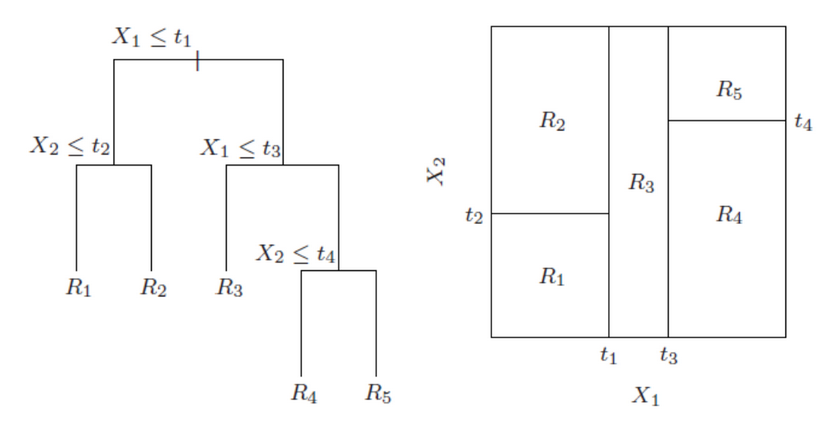

- Considerar todas las particiones posibles es **inviable**
- La alternativa es un algoritmo **voraz**: en cada paso elige el mejor corte para ese paso (**óptimo local**), sin mirar si otro daría un árbol mejor en los pasos siguientes (**óptimo global**)

## Partición binaria recursiva

- La **partición binaria recursiva** construye el árbol de arriba abajo (más detalles):
  1. todas las observaciones empiezan en una sola región, con la media de $y$ como predicción
  2. para **cada** variable $X_j$ y **cada** umbral $s$ se calcula la SCR que quedaría al partir en $\{X_j < s\}$ y $\{X_j \geq s\}$, con la media de cada parte como predicción
  3. se hace solo la partición que más baja la SCR, y se repite el paso 2 dentro de cada una de las dos regiones
  4. se para cuando la región es pequeña, cuando el árbol llega a una profundidad o cuando ningún corte mejora bastante

El primer corte con solo `edad` y `renta`: se recorren **todos** los umbrales de cada variable

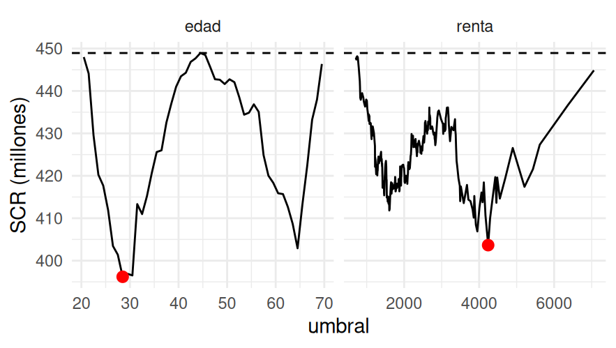

| Corte | SCR (millones) |
| --- | --- |
| `edad` < 24,5 | 418 |
| **`edad` < 28,5** | **396** |
| `edad` < 45,5 | 448 |
| `edad` < 64,5 | 403 |
| `renta` < 4.240 (su mejor corte) | 404 |

## Dos variables: rectángulos y reglas

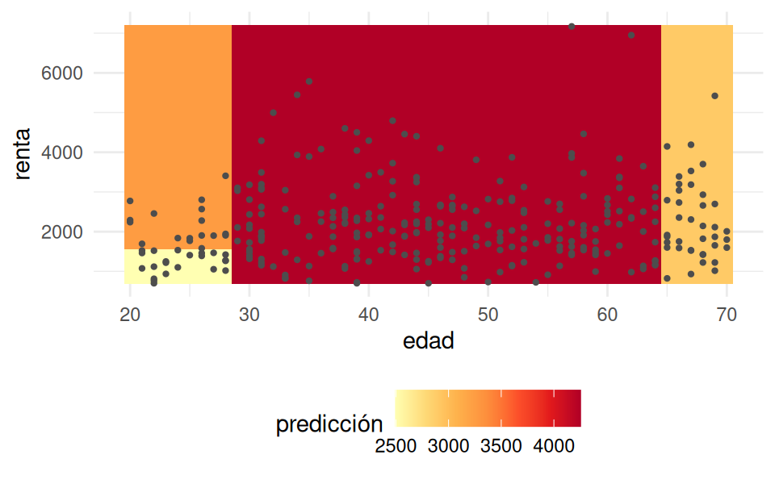

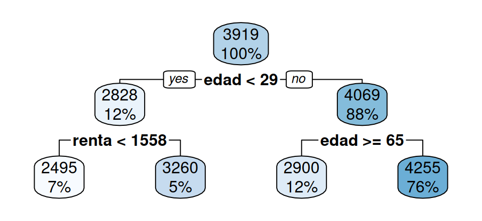

- Es el árbol de profundidad 2 con `edad` y `renta`: el primer corte es el de la transparencia anterior
- Cada caja da la media de las ventas de sus clientes y el porcentaje de clientes que caen en ella
- Las reglas se leen de arriba abajo: «un cliente de 25 años con 1.200 euros de renta gasta 2.495 euros, la media de los 22 clientes de su hoja»
- El árbol ha encontrado una **interacción** sin que nadie la escribiera: la renta solo importa por debajo de cierta edad

## Podar: el coste de complejidad

- Un árbol que crece sin límite es demasiado complejo: **sobreajusta** (*overfitting*)
- La **poda** hace crecer un árbol grande, $T_0$, y se queda con el subárbol $T$ que minimiza
  $$\small \sum_{m=1}^{|T|} \sum_{i \in R_m} (y_i - \bar y_{R_m})^2 + \alpha\, |T|$$
  donde $|T|$ es el número de nodos terminales de $T$ donde $R_m$ es la región del nodo terminal $m$
- $\alpha \geq 0$ es el **coste de complejidad**: penaliza los nodos terminales, como el LASSO el tamaño de los coeficientes
  - más nodos terminales ajustan mejor (menos SCR), pero pagan más penalización
  - con $\alpha$ pequeño, el árbol sobreajusta; con $\alpha$ grande, quedan pocas hojas
- $\alpha$ se elige por validación cruzada, como $\lambda$ en el LASSO

## El árbol en `tidymodels`: `decision_tree()`

```r
arbol <- decision_tree(cost_complexity = 0.01, tree_depth = 2, min_n = 20) |>
  set_engine("rpart") |> set_mode("regression")      # el modelo
flujo <- workflow(ventas ~ ., arbol)                 # el flujo: fórmula (o receta) y modelo
arbol_est <- flujo |> fit(training(part))            # el modelo estimado
extract_fit_engine(arbol_est)                        # el árbol, en texto
rpart.plot(extract_fit_engine(arbol_est))            # el árbol, dibujado
```

- La gramática del Tema 07, con otro modelo:
  - el **modelo**: `decision_tree()`, con el motor (`rpart`; también `C5.0`, solo para clasificación, o `spark`) y el modo, regresión o clasificación
  - el **flujo**: la fórmula (o una receta) y el modelo, con `workflow()`
  - el **modelo estimado**: `fit()` del flujo con los datos
  - en lugar de los coeficientes de MCO, se extrae y se muestra el **árbol**, en texto o dibujado
- Tres hiperparámetros, que se pueden afinar por validación cruzada, uno o varios a la vez:
  - `cost_complexity`: el coste de complejidad $\alpha$ de la poda
  - `tree_depth`: número máximo de cortes seguidos desde la raíz
  - `min_n`: observaciones mínimas en una región para seguir partiéndola
- Con las seis variables y profundidad 2, el árbol corta por `mujer` y después, entre las mujeres, por `renta`: la interacción del Tema 05, encontrada sola

## Árboles de clasificación

- Un árbol de **clasificación** predice una $y$ cualitativa: en cada región, la **clase mayoritaria**
  - también da la proporción $\hat p_{mk}$ de observaciones de la clase $k$ en la región $m$, que hace de probabilidad
- Se construye igual, pero la SCR no se puede calcular
  - el corte se elige con medidas de **pureza** de la región; la habitual es el **índice de Gini**:
    $$\small G_m = \sum_{k=1}^{K} \hat p_{mk}\,(1 - \hat p_{mk})$$
  - vale 0 si todas son de la misma clase y es máximo cuando las clases están repartidas por igual (0,5 con dos clases)
- En `churn`, la raíz tiene un 60 % de abandonos: $G = 2 \times 0{,}60 \times 0{,}40 = 0{,}48$
  - el corte `satisfaccion < 3.5` deja regiones con 74 % y 49 %, y el Gini medio baja a 0,45: ningún otro corte baja más

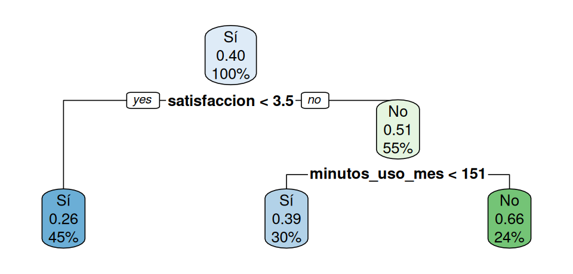

```r
arbol_c <- decision_tree(
  tree_depth = 2) |>
  set_engine("rpart") |>
  set_mode("classification")
flujo_c <- workflow(churn ~ ., arbol_c)
arbol_c_est <- flujo_c |>
  fit(training(part_c))
extract_fit_engine(arbol_c_est) |>
  rpart.plot()
```

- La poda se realiza de la misma manera

## Comentarios sobre los árboles

- Predicción: la media (o la clase mayoritaria) del nodo terminal donde cae la observación nueva
- **Importancia** de una variable: cuánto contribuye a las predicciones del árbol
  - se calcula sumando lo que reducen la SCR (o el Gini) todos los cortes que usan esa variable
  - el árbol estimado la trae calculada: `extract_fit_engine(arbol_est)$variable.importance`
- **Ventajas**
  - es un método no paramétrico: no supone ninguna forma funcional, y las no linealidades y las interacciones salen de los cortes sucesivos, sin escribirlas
  - no necesita logaritmos, polinomios, dummies ni estandarizar: `log(renta)` da los mismos grupos, porque el logaritmo no cambia el orden (el corte puede caer en otro punto)
  - es fácil de explicar y de visualizar
- **Inconvenientes**
  - sobreajusta: por eso es inestable (cambiar unos pocos clientes cambia el primer corte y todo lo que cuelga de él) y predice peor
  - no extrapola: a un cliente de 80 años le predice lo mismo que a uno de 70, la media de la última hoja

## PRÁCTICA en clase (1): la regla de los dependientes

**Nota**

**Ahora el ejercicio: entrega 1, apartados a) a e).**

# Bosques aleatorios

## Bagging: promediar muchos árboles

- Un árbol tiene poco sesgo y **mucha varianza**, y promediar reduce la varianza: la media de $n$ observaciones independientes tiene varianza $\sigma^2/n$
- ¿De dónde salen muchos árboles con una sola muestra? Del **bootstrap** del Tema 05: $B$ remuestras con reemplazamiento del entrenamiento
  - en cada remuestra se ajusta un árbol grande, sin podar, $\hat f^b(x)$
  - la predicción es la media de los $B$ árboles, $\hat f_{bag}(x) = \frac{1}{B} \sum_{b} \hat f^b(x)$, o en clasificación la clase más votada
- En lugar de un único árbol complejo, se combinan muchos árboles diversos que pueden reflejar patrones sutiles
  - cada árbol sobreajusta su remuestra, pero sobreajusta cosas distintas, y al promediar se cancelan
  - se gana predicción a costa de **interpretación**: la media de 500 árboles ya no se lee como un árbol
- Cada remuestra deja fuera, de media, un tercio de las observaciones: con ellas se estima el error *out-of-bag*

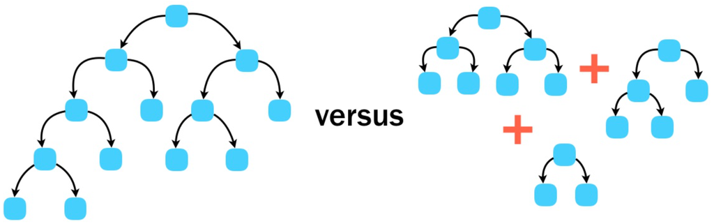

## Random forest: `mtry` descorrelaciona los árboles

- Promediar solo ayuda si los árboles son **distintos**: si fueran todos iguales, la media sería ese mismo árbol y no se ganaría nada
  - en bagging, una variable fuerte hace que todos empiecen igual: con la tienda, los 500 empiezan por `mujer` y se parecen mucho (están **correlacionados**)
- El **bosque aleatorio** (*random forest*) añade un sorteo: en **cada corte** solo se consideran `mtry` variables elegidas al azar de las $p$
  - con `mtry` $= p$ es bagging; `ranger` toma por defecto $\sqrt{p}$, redondeada hacia abajo, y otra opción habitual en regresión es $p/3$
- Con menos variables en cada corte, dos fuerzas en sentido contrario:
  - la fuerte entra en menos cortes: los árboles se parecen menos (se **descorrelacionan**) y el promedio reduce más la varianza
  - cada árbol es **peor**
- Medidas en la tienda con 500 árboles:

| `mtry` | correlación entre árboles | RMSE de un árbol suelto | RMSE del promedio | primer corte de los 500 árboles |
| --- | --- | --- | --- | --- |
| 6 (bagging) | 0,90 | 592 | 435 | `mujer` en todos |
| 2 | 0,69 | 815 | 515 | `mujer` 171, `edad` 119, `renta` 108 |
| 1 | 0,41 | 1.045 | 824 | al azar |

- En la tienda, con tres variables fuertes de seis, pesa más lo segundo: conviene el bagging o casi

## `rand_forest()` y su afinado

- El **modelo**: `rand_forest()`, con el motor (`ranger`; también `randomForest`, `spark` o `grf`) y el modo
- Hiperparámetros:
  - `mtry`, el principal: se afina por validación cruzada
  - `min_n` se podría afinar, pero no suele hacerse: el promedio ya reduce la varianza de árboles profundos
  - `trees` no se afina: más árboles no sobreajustan; cuantos más, mejor: basta con que el error se estabilice

```r
bosque <- rand_forest(mtry = tune(), trees = 500) |>
  set_engine("ranger") |> set_mode("regression")
flujo_b <- workflow(ventas ~ ., bosque)
rejilla_b <- grid_regular(mtry(range = c(1, 6)),
                          levels = 6)  # las 6
set.seed(12345678)  # sortea remuestras y variables
ajuste_b <- tune_grid(flujo_b, resamples = bloques,
                      grid = rejilla_b,
                      metrics = metric_set(rmse))
mejor_b <- select_best(ajuste_b, metric = "rmse")
set.seed(12345678)
final_b <- finalize_workflow(flujo_b, mejor_b) |>
  last_fit(part, metrics = metric_set(rmse, mae))
autoplot(ajuste_b)
```

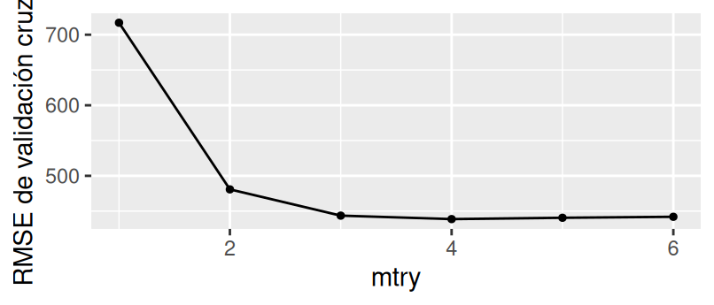

- De 1 a 3 el RMSE cae de golpe (717, 481, 444) y de 3 a 6 es una meseta (439 a 444): `select_best()` da 4, y `last_fit()` **430** en prueba
- Con `min_n` = 1, 5, 20 y 50 salen 426, 430, 467 y 523 en prueba: con un `min_n` mayor se deja de partir antes, los árboles son más pequeños y el bosque predice peor

## Importancia de las variables

- Un bosque de 500 árboles no se puede dibujar; lo que se aprende de él es la **importancia** de cada variable: cuánto la usa el algoritmo para predecir
- Dos formas de medirla:
  - **por permutación**: se barajan los valores de $X_j$ y se mira cuánto empeora la predicción; si apenas empeora, la variable aporta poco a la predicción
  - **por impureza**: la de un árbol, sumada en todos los árboles del bosque

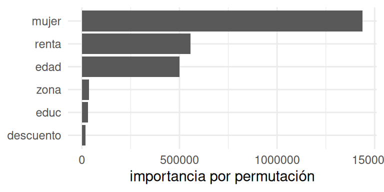

```r
bosque_imp <- rand_forest(mtry = 4, trees = 500) |>
  set_engine("ranger",
             importance = "permutation") |>
  set_mode("regression")
set.seed(12345678)
bosque_est <- workflow(ventas ~ ., bosque_imp) |>
  fit(training(part))
imp <- extract_fit_engine(bosque_est)$
  variable.importance
tibble(variable = names(imp), importancia = imp) |>
  ggplot(aes(importancia,
             fct_reorder(variable, importancia))) +
  geom_col()
```

- `mujer`, `renta` y `edad` mandan; `descuento` queda la **última**

## Predecir o interpretar

- El bosque gana predicción a costa de **interpretación**
- La importancia dice qué usa el algoritmo para predecir, y nada sobre qué pasaría al cambiar la variable: predecir y estimar efectos son preguntas distintas
  - el descuento queda el último en importancia: lo tiene el 15 % de los clientes, los de renta baja, y un corte por `renta` ya recoge casi todo lo que aporta a la predicción
  - pero tiene efecto: +500 euros en el Tema 05
- Para **interpretar**, como en el Tema 05, hacen falta otras cosas:
  - un árbol podado se lee, y sus reglas pueden ayudar a tomar decisiones
  - como con LASSO, las variables más importantes, y las interacciones y no linealidades que sugieren, pueden servir para estimar de nuevo un modelo lineal o logit que sí se interpreta
- Otras herramientas de interpretación, para ver cómo usa el modelo cada variable, en el anexo

## PRÁCTICA en clase (2): el presupuesto del año que viene

Dirección tiene que fijar el presupuesto de compras del año que viene y quiere la **mejor predicción posible** del gasto de cada cliente; aquí la regla legible no importa. Con vuestro DNI como semilla, `part` y `bloques`:

1. Ajustad un bosque con `mtry = 6` y 500 árboles, que es bagging, y calculad su RMSE en prueba. Comparadlo con el árbol podado de la práctica 1: ¿cuánto se gana solo por promediar?
2. Afinad `mtry` de 1 a 6 con `tune_grid()` sobre `bloques`. Comentad brevemente la forma de la curva y explicad con las dos fuerzas cómo cambia el RMSE según el valor de `mtry`
3. Con el mejor `mtry`, ajustad bosques de 10, 100, 500 y 2.000 árboles y medid el RMSE de prueba. Discutid cómo elegiríais el valor de `trees`, y por qué
4. Calculad la importancia por permutación del mejor bosque y ordenadla. Dirección lee que `descuento` sale la última y propone **suprimir** el descuento porque «no sirve». Explicad por qué esa lectura confunde dos preguntas. Calculadla con `importance = "impurity_corrected"`.

**Nota**

**Ahora el ejercicio: entrega 2, apartados a) a d).**

# Boosting

## Boosting: aprender de los residuos

- En **boosting** los árboles se construyen **en secuencia**: cada árbol se ajusta a lo que los anteriores todavía hacen mal
  - en bagging y en el bosque, en paralelo, cada uno sobre su remuestra, y se promedian
- El algoritmo (*gradient boosting*), con $B$ árboles pequeños y una **tasa de aprendizaje** $\eta$:
  1. se empieza con la media: $\hat f_0(x) = \bar y$
  2. para $b = 1, \dots, B$:
     - se calculan los residuos del modelo acumulado, $r_i = y_i - \hat f_{b-1}(x_i)$
     - se ajusta un árbol pequeño $g_b$ a esos **residuos**, con todas las observaciones
     - se suma una fracción: $\hat f_b(x) = \hat f_{b-1}(x) + \eta\, g_b(x)$
  3. la predicción final es $\hat f_B(x) = \bar y + \eta \sum_{b=1}^{B} g_b(x)$
- $\eta$ es el freno, normalmente entre 0,01 y 0,1: cada árbol corrige solo una parte del error, y el modelo aprende **despacio**
  - como añadir términos a una regresión para explicar lo que dejó sin explicar
- Cada árbol es **débil** a propósito (`tree_depth` de 1 a 3), y no hay remuestras ni promedio: hay una suma (un ejemplo sencillo)

## `boost_tree()` y el número de árboles

- El **modelo**: `boost_tree()`, con el motor (`xgboost`; también `C5.0`, solo para clasificación, o `spark`) y el modo
- Hiperparámetros: `trees` ($B$), `learn_rate` ($\eta$) y `tree_depth`
  - aquí `trees` **sí sobreajusta**: con muchos árboles, los residuos que ajusta cada árbol nuevo ya son ruido; se afina por validación cruzada
- `xgboost` solo admite predictores numéricos: con una fórmula crea las dummies solo; con una receta hace falta `step_dummy(all_nominal_predictors())`

```r
boosting <- boost_tree(trees = tune(), tree_depth = 2,
                       learn_rate = 0.1) |>
  set_engine("xgboost") |> set_mode("regression")
flujo_x <- workflow(ventas ~ ., boosting)
rejilla_x <- grid_regular(  # rango en log10: de 10^1 a 10^3,2
  trees(range = c(1, 3.2), trans = transform_log10()),
  levels = 8)  # de 10 a 1.584
ajuste_x <- tune_grid(flujo_x, resamples = bloques,
                      grid = rejilla_x,
                      metrics = metric_set(rmse))
mejor_x <- select_best(ajuste_x, metric = "rmse")
final_x <- finalize_workflow(flujo_x, mejor_x) |>
  last_fit(part, metrics = metric_set(rmse, mae))
autoplot(ajuste_x)
```

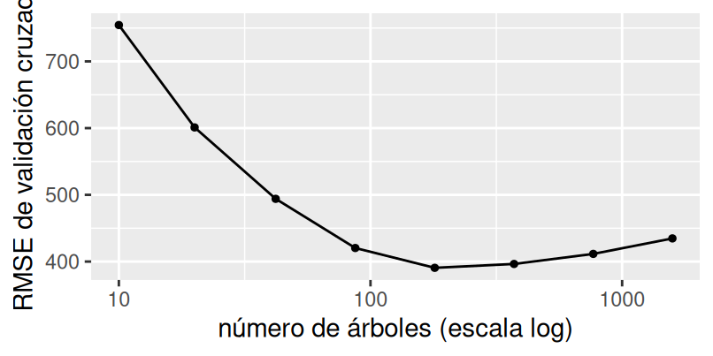

- La U está en **180** árboles (391 de validación cruzada); con 1.584 sube a 435
- En prueba, con 180 árboles: **358** euros, 72 menos que el bosque

## `learn_rate` y `tree_depth`

| `learn_rate` ($\eta$), 180 árboles | RMSE de VC |
| --- | --- |
| 0,01 | 646 |
| 0,03 | 467 |
| 0,1 | **391** |
| 0,3 | 410 |
| 1 | 482 |

- Con $\eta = 0{,}01$ el modelo se queda corto: necesitaría más árboles; con $\eta = 1$ corre demasiado y sobreajusta

| `tree_depth`, 180 árboles y $\eta = 0{,}1$ | RMSE de VC |
| --- | --- |
| 1 (tocón) | 545 |
| 2 | **391** |
| 3 | 409 |
| 4 | 421 |

- Con profundidad 1 el modelo es aditivo y no capta la interacción `mujer × renta`; con más, cada árbol empieza a sobreajustar
- Regla práctica: fijar dos hiperparámetros, de ordinario $\eta$ (entre 0,01 y 0,1) y la profundidad (entre 1 y 3), y afinar `trees` por validación cruzada
  - Lo estricto es afinar los tres a la vez (`grid_space_filling()`), porque el mejor valor de cada uno depende de los otros dos; tarda mucho
  - Se puede afinar uno cada vez, como aquí, pero el $\eta$ que sale con `trees` y profundidad fijos no tiene por qué ser el mejor cuando se mueven los tres

```r
boost_eta  <- boost_tree(trees = 180, tree_depth = 2, learn_rate = tune()) |>
  set_engine("xgboost") |> set_mode("regression")
ajuste_eta <- tune_grid(workflow(ventas ~ ., boost_eta), resamples = bloques,
                        grid = grid_regular(learn_rate(range = c(-2, 0)), levels = 5),
                        metrics = metric_set(rmse))
```

## PRÁCTICA en clase (3): boosting

Dirección quiere saber si el boosting mejora al bosque en la predicción del gasto. Con vuestro DNI como semilla, `part` y `bloques`:

1. Afinad `trees` con la rejilla de la transparencia. ¿Cuál es el mejor valor? ¿Qué pasa con 1.584 árboles? Comparadlo con lo que pasaba con `trees` en el bosque de la práctica 2. Añadid `tree_method = "exact"` en `set_engine()`.
2. Con el mejor `trees`, ajustad el boosting con `learn_rate` = 0,01 y medid su RMSE de prueba. Repetidlo con 1.000 y 3.000 árboles, y después con `learn_rate` = 1. ¿Qué pasa en cada caso al aumentar los árboles, y por qué?
3. Evaluad en prueba el mejor boosting con `last_fit()` y ponedlo al lado del árbol podado, del bosque y del LASSO del Tema 07 (el RMSE de prueba de vuestro `final`). ¿Cuál gana en la tienda, y por qué? ¿En qué datos esperaríais lo contrario?

**Nota**

**Ahora el ejercicio: entrega 3, apartados a) a c).**

## Los modelos en prueba

| Tienda: modelo | RMSE en prueba |
| --- | --- |
| Lineal con las variables tal cual | 755 |
| LASSO con la forma funcional del Tema 05 | **340** |
| Árbol podado | 530 |
| Bosque aleatorio | 430 |
| Boosting | 358 |

- Para **predecir**, el LASSO gana por poco: le dimos una forma muy flexible (polinomios, escalones, interacciones) y eligió dentro de ella
  - aquí esa aproximación funciona; en otros datos puede no funcionar
  - sin escribir ninguna forma, el boosting queda a 18 euros
- Para **interpretar**, el boosting está como el bosque: importancia, y después un modelo que se lea
- Los mismos modelos en Python, en el anexo

## PRÁCTICA en clase (4): el mejor modelo de abandono

La empresa de suscripción del Tema 06 decide a quién hacer la oferta de retención con el modelo que mejor ordene a los clientes por su riesgo, y lo quiere evaluado con clientes que el modelo no haya visto. Con vuestro DNI como semilla y `part_c` y `bloques_c` como en el Tema 07:

1. Afinad `mtry` de un bosque de 500 árboles con `grid_regular(mtry(range = c(1, 21)), levels = 7)`. Comparad el mejor `mtry` con el de la tienda y explicad la diferencia con las variables de cada base de datos. ¿Es grande la ventaja frente al bagging, comparada con el error estándar?
2. Afinad por AUC un boosting con `tree_depth = 2`, `learn_rate = 0.1` y `trees` en la rejilla de la transparencia, con una receta `churn ~ .` y `step_dummy(all_nominal_predictors())`. Repetidlo con `tree_depth = 1`, comparad y explicad qué dice el resultado sobre las señales de abandono. Añadid `step_YeoJohnson(all_numeric_predictors())` a la receta.
3. Evaluad en prueba con `last_fit()` el mejor bosque y el mejor boosting, y ponedlos en una tabla con el LASSO del Tema 07 y con un árbol podado (afinad `cost_complexity` por AUC, como en la práctica 1). ¿Con cuál se queda la empresa? ¿Qué pierde respecto al LASSO, y qué cautela añade el tamaño de la prueba?

**Nota**

**Ahora el ejercicio: entrega 4, apartados a) a c).**